# Week 1 — Fundamentals

This week has two halves.

The **lecture** is about the process: what a statistical question looks like, what a variable is, what a sample is for, and how to describe data honestly.

This **notebook** is the practical half. By the end of it you will be able to load a dataset, find out what is in it, and describe it — which is the first thing you will do in every week that follows.

Nothing here assumes you have used Python for data before.

## Part 1 — The tools

Three pieces:

| Tool | What it is for |
| --- | --- |
| **Python** | the language |
| **pandas** | tabular data — a spreadsheet you can program |
| **`math9102`** | this module's own helper package |

`math9102` is deliberately thin. It supplies the module's datasets, its house figure style, and the reporting functions — the things you would otherwise copy and paste every week. Everything statistical is done with **scipy**, **statsmodels** and **pingouin** directly, because those are the tools you will use after this module ends.

```python
import math9102 as m9
import numpy as np
import pandas as pd

m9.use_house_style()
```

If that cell ran without error, your environment is working.

### Why the environment is pinned

Every version of every package this module uses is fixed in `requirements.lock`. That is not bureaucracy. An analysis that gives one answer on your machine and another on mine is not an analysis, and the version of a package is part of the method.

You will meet scripts that install packages at the top, inside a wrapper that suppresses all errors. If the install fails, the script carries on and fails later somewhere unrelated. Don't do that.

## Part 2 — Values, Series and DataFrames

A **variable** in Python holds a value.

```python
income = 100
taxes = 20
net_income = income - taxes
net_income
```

```
80
```

A **Series** holds many values of the same kind, and arithmetic applies to all of them at once.

```python
age = pd.Series([28, 48, 47, 71, 22, 80, 48, 30, 31])
age * 12
```

```
0    336
1    576
2    564
3    852
4    264
5    960
6    576
7    360
8    372
dtype: int64
```

```python
print(age.min(), age.max(), age.sum())
```

```
22 80 405
```

A **DataFrame** holds several Series side by side, sharing one index — one row per case.

```python
purchase = pd.Series([20, 59, 2, 12, 22, 160, 34, 34, 29])
techsales = pd.DataFrame({"age": age, "purchase": purchase})
techsales
```

|  | age | purchase |
| --- | --- | --- |
| 0 | 28 | 20 |
| 1 | 48 | 59 |
| 2 | 47 | 2 |
| 3 | 71 | 12 |
| 4 | 22 | 22 |
| 5 | 80 | 160 |
| 6 | 48 | 34 |
| 7 | 30 | 34 |
| 8 | 31 | 29 |

Selecting rows by a condition:

```python
techsales[techsales.age > 40]
```

|  | age | purchase |
| --- | --- | --- |
| 1 | 48 | 59 |
| 2 | 47 | 2 |
| 3 | 71 | 12 |
| 5 | 80 | 160 |
| 6 | 48 | 34 |

Deriving a new column. Note that the categories are **mutually exclusive** and **collectively exhaustive** — every row falls into exactly one:

```python
techsales["band"] = pd.cut(
    techsales.purchase,
    bins=[-np.inf, 20, 100, np.inf],
    labels=["cheap", "reasonable", "expensive"],
)
techsales
```

|  | age | purchase | band |
| --- | --- | --- | --- |
| 0 | 28 | 20 | cheap |
| 1 | 48 | 59 | reasonable |
| 2 | 47 | 2 | cheap |
| 3 | 71 | 12 | cheap |
| 4 | 22 | 22 | reasonable |
| 5 | 80 | 160 | expensive |
| 6 | 48 | 34 | reasonable |
| 7 | 30 | 34 | reasonable |
| 8 | 31 | 29 | reasonable |

## Part 3 — Loading a dataset

**Datasets are loaded by name, never by path.**

```python
salaries = m9.load_salaries()
salaries.shape
```

```
(397, 6)
```

That is a rule, not a convenience. An absolute path is a fact about one computer — whose account, which drive, which folder — so an analysis that hardcodes one runs on that machine and nowhere else. A dataset name is a fact about the analysis, and it travels.

To see what is available:

```python
m9.available()
```

```
['bdi',
 'bullying',
 'experim',
 'experim_clean',
 'facebook_narcissism',
 'festival',
 'festival_no_outlier',
 'msleep',
 'raq',
 'regression',
 'romcom',
 'romcom_urbanrural',
 'salaries',
 'sleep',
 'survey',
 'websatisfaction',
 'wine',
 'youthcohort']
```

Every dataset carries its provenance — where it came from, its checksum, and anything you need to know before using it:

```python
m9.manifest().set_index("dataset").loc[["salaries", "msleep"], ["rows", "cols", "note"]]
```

| dataset | rows | cols | note |
| --- | --- | --- | --- |
| salaries | 397 | 6 | US academic salaries 2008-09, 397x6 (carData::... |
| msleep | 83 | 11 | Mammal sleep times, 83x11 (ggplot2::msleep, af... |

### What is in this one?

`salaries` records nine-month academic salaries at one US college in 2008–09.

```python
salaries.head()
```

|  | rank | discipline | yrs_since_phd | yrs_service | sex | salary |
| --- | --- | --- | --- | --- | --- | --- |
| 0 | Prof | B | 19 | 18 | Male | 139750 |
| 1 | Prof | B | 20 | 16 | Male | 173200 |
| 2 | AsstProf | B | 4 | 3 | Male | 79750 |
| 3 | Prof | B | 45 | 39 | Male | 115000 |
| 4 | Prof | B | 40 | 41 | Male | 141500 |

```python
salaries.dtypes
```

```
rank               str
discipline         str
yrs_since_phd    int64
yrs_service      int64
sex                str
salary           int64
dtype: object
```

```python
salaries.info()
```

```
<class 'pandas.DataFrame'>
RangeIndex: 397 entries, 0 to 396
Data columns (total 6 columns):
 #   Column         Non-Null Count  Dtype
---  ------         --------------  -----
 0   rank           397 non-null    str
 1   discipline     397 non-null    str
 2   yrs_since_phd  397 non-null    int64
 3   yrs_service    397 non-null    int64
 4   sex            397 non-null    str
 5   salary         397 non-null    int64
dtypes: int64(3), str(3)
memory usage: 18.7 KB
```

Read `dtypes` carefully. Python's type is **not** the same thing as the statistical level of measurement:

| Column | Python type | Level of measurement |
| --- | --- | --- |
| `rank` | object (text) | ordinal — assistant, associate, full |
| `discipline` | object (text) | nominal — theoretical or applied |
| `sex` | object (text) | nominal |
| `yrs_since_phd` | int | ratio — a true zero, and twice as many years means twice as long |
| `yrs_service` | int | ratio |
| `salary` | int | ratio |

Python cannot tell you which column is ordinal. **That is your judgement, and it decides which statistics are legitimate.**

## Part 4 — Describing a categorical variable

For a categorical variable there is only one honest summary: **how many, and what share**.

```python
m9.frequency(salaries, "rank")
```

| rank | count | percent | valid_percent |
| --- | --- | --- | --- |
| AssocProf | 64 | 16.12 | 16.12 |
| AsstProf | 67 | 16.88 | 16.88 |
| Prof | 266 | 67.00 | 67.00 |

```python
m9.frequency(salaries, "discipline")
```

| discipline | count | percent | valid_percent |
| --- | --- | --- | --- |
| A | 181 | 45.59 | 45.59 |
| B | 216 | 54.41 | 54.41 |

Two categorical variables together give a contingency table:

```python
m9.crosstab(salaries, "discipline", "rank")
```

| rank discipline | AssocProf | AsstProf | Prof |
| --- | --- | --- | --- |
| A | 26 | 24 | 131 |
| B | 38 | 43 | 135 |

Counts alone are hard to compare when the row totals differ. Percentages **within rows** answer "of the people in this discipline, what share hold each rank?":

```python
m9.crosstab(salaries, "discipline", "rank", normalize="index")
```

| rank discipline | AssocProf | AsstProf | Prof |
| --- | --- | --- | --- |
| A | 14.4 | 13.3 | 72.4 |
| B | 17.6 | 19.9 | 62.5 |

Percentages **within columns** answer a different question — "of the people at this rank, what share are in each discipline?":

```python
m9.crosstab(salaries, "discipline", "rank", normalize="columns")
```

| rank discipline | AssocProf | AsstProf | Prof |
| --- | --- | --- | --- |
| A | 40.6 | 35.8 | 49.2 |
| B | 59.4 | 64.2 | 50.8 |

Both are correct. They answer different questions, and a table of percentages that does not say which way it was computed is unreadable. **Always say.**

## Part 5 — Central tendency

Three summaries of "the typical value", and they do not agree.

```python
print(f"mean   = {salaries.salary.mean():,.0f}")
print(f"median = {salaries.salary.median():,.0f}")
print(f"mode   = {salaries.salary.mode().iloc[0]:,.0f}")
```

```
mean   = 113,706
median = 107,300
mode   = 92,000
```

The mean is higher than the median. That is the signature of a **right-skewed** distribution: a tail of large values pulls the mean up, and the median does not follow.

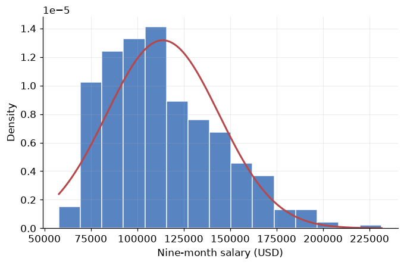

```python
m9.histogram_with_normal(salaries.salary, xlabel="Nine-month salary (USD)");
```

### Which one should you report?

- **Mode** — the only one available for a nominal variable.
- **Median** — the middle value. Unaffected by how extreme the extremes are.
- **Mean** — uses every value, which is its strength and its weakness.

A worked illustration. Consider a neighbourhood of twenty people earning a modest wage, one earning rather more, five professionals, and a film star:

```python
neighbourhood = pd.Series([10_000] * 20 + [35_000] + [150_000] * 5 + [4_465_000])

print(f"mode   = {neighbourhood.mode().iloc[0]:,.0f}")
print(f"median = {neighbourhood.median():,.0f}")
print(f"mean   = {neighbourhood.mean():,.0f}")
```

```
mode   = 10,000
median = 10,000
mean   = 201,852
```

Nobody in that street earns anything close to the mean. It is not a wrong calculation; it is a misleading summary, and reporting it alone would be a choice you would have to defend.

> There is an old story about the statistician who drowned crossing a lake with an average depth of three feet.

## Part 6 — Dispersion

A measure of the centre means little without a measure of the spread.

```python
salary = salaries.salary

print(f"range    = {salary.max() - salary.min():,.0f}")
print(f"IQR      = {salary.quantile(.75) - salary.quantile(.25):,.0f}")
print(f"variance = {salary.var(ddof=1):,.0f}")
print(f"SD       = {salary.std(ddof=1):,.0f}")
```

```
range    = 173,745
IQR      = 43,185
variance = 917,425,865
SD       = 30,289
```

**Range** is the distance from smallest to largest. It uses two observations and ignores the other several hundred, so a single extreme value sets it.

**IQR** is the width of the middle half. It ignores the tails by construction, which is exactly why it survives them.

**Variance** is the average squared distance from the mean. Squaring stops positive and negative deviations cancelling — and it is preferred to taking absolute values because the squared version has the mathematical properties the rest of statistics is built on.

**Standard deviation** is the square root of the variance, which puts it back into the units of the original variable. That is why it is the one you report.

### Why `ddof=1`

```python
print(f"pandas default (ddof=1): {salary.std():,.3f}")
print(f"numpy  default (ddof=0): {np.std(salary):,.3f}")
```

```
pandas default (ddof=1): 30,289.039
numpy  default (ddof=0): 30,250.867
```

`ddof` is the divisor correction: with `ddof=1` you divide by one less than the number of observations. Estimating the mean from the sample uses up one piece of information, so only the rest are free to vary. **pandas defaults to `ddof=1`, numpy defaults to `ddof=0`.** They will silently disagree. Know which you are using.

### Reading a standard deviation

For a roughly **normal** distribution, about two thirds of observations fall within one standard deviation of the mean, and almost all within three. Week 2 makes this exact. `salary` is not normal — it has the right tail you saw above — so treat the rule as a sanity check, and notice how close it still lands:

```python
lower, upper = salary.mean() - salary.std(), salary.mean() + salary.std()
inside = salary.between(lower, upper).mean()

print(f"within one SD of the mean: {inside:.1%}")
print(f"interval: {lower:,.0f} to {upper:,.0f}")
```

```
within one SD of the mean: 65.0%
interval: 83,417 to 143,995
```

Two groups can share a mean and be entirely different. Suppose two programmes have the same mean exam mark but different standard deviations:

```python
for sd in (1.6, 4.3):
    print(f"SD {sd}: about two thirds of marks between "
          f"{60 - sd:.1f} and {60 + sd:.1f}, "
          f"almost all between {60 - 3 * sd:.1f} and {60 + 3 * sd:.1f}")
```

```
SD 1.6: about two thirds of marks between 58.4 and 61.6, almost all between 55.2 and 64.8
SD 4.3: about two thirds of marks between 55.7 and 64.3, almost all between 47.1 and 72.9
```

Same centre, very different student experience. Reporting only the mean would hide it.

## Part 7 — The whole description at once

```python
m9.describe(salaries, ["salary", "yrs_since_phd", "yrs_service"])
```

|  | n | missing | mean | sd | se | median | iqr | min | max | skew | kurtosis |
| --- | --- | --- | --- | --- | --- | --- | --- | --- | --- | --- | --- |
| salary | 397 | 0 | 113706.458 | 30289.039 | 1520.163 | 107300.0 | 43185.0 | 57800.0 | 231545.0 | 0.715 | 0.215 |
| yrs_since_phd | 397 | 0 | 22.315 | 12.887 | 0.647 | 21.0 | 20.0 | 1.0 | 56.0 | 0.301 | -0.794 |
| yrs_service | 397 | 0 | 17.615 | 13.006 | 0.653 | 16.0 | 20.0 | 0.0 | 60.0 | 0.651 | -0.311 |

`skew` and `kurtosis` describe the **shape**:

- **Skew** — positive means a tail to the right, negative a tail to the left, zero means symmetric.
- **Kurtosis** — how much of the variance comes from rare extreme values rather than from typical ones.

Treat both as descriptions, not as verdicts. We come back to them in week 3.

And split by a group:

```python
m9.describe_by(salaries, "salary", "discipline")
```

| discipline | n | missing | mean | sd | se | median | iqr | min | max | skew | kurtosis |
| --- | --- | --- | --- | --- | --- | --- | --- | --- | --- | --- | --- |
| A | 181.0 | 0.0 | 108548.431 | 30538.146 | 2269.882 | 104350.0 | 42192.00 | 57800.0 | 205500.0 | 0.853 | 0.423 |
| B | 216.0 | 0.0 | 118028.694 | 29459.135 | 2004.440 | 113018.5 | 44931.25 | 67559.0 | 231545.0 | 0.677 | 0.225 |

## Part 8 — Missing data, on day one

Real datasets are incomplete. The lab dataset is a good example.

```python
msleep = m9.load_msleep()
msleep.head()
```

|  | name | genus | vore | order | conservation | sleep_total | sleep_rem | sleep_cycle | awake | brainwt | bodywt |
| --- | --- | --- | --- | --- | --- | --- | --- | --- | --- | --- | --- |
| 0 | Cheetah | Acinonyx | carni | Carnivora | lc | 12.1 | NaN | NaN | 11.9 | NaN | 50.000 |
| 1 | Owl monkey | Aotus | omni | Primates | NaN | 17.0 | 1.8 | NaN | 7.0 | 0.01550 | 0.480 |
| 2 | Mountain beaver | Aplodontia | herbi | Rodentia | nt | 14.4 | 2.4 | NaN | 9.6 | NaN | 1.350 |
| 3 | Greater short-tailed shrew | Blarina | omni | Soricomorpha | lc | 14.9 | 2.3 | 0.133333 | 9.1 | 0.00029 | 0.019 |
| 4 | Cow | Bos | herbi | Artiodactyla | domesticated | 4.0 | 0.7 | 0.666667 | 20.0 | 0.42300 | 600.000 |

```python
msleep.isna().sum()
```

```
name             0
genus            0
vore             7
order            0
conservation    29
sleep_total      0
sleep_rem       22
sleep_cycle     51
awake            0
brainwt         27
bodywt           0
dtype: int64
```

More than half the animals have no recorded sleep cycle. That is not a defect in the data — it is a fact about how hard that measurement is to take — but it governs what you can say.

```python
missing = m9.missingness(msleep, ["sleep_total", "vore", "bodywt"])
print(missing.attrs["summary"])
missing
```

```
Listwise deletion across these 3 column(s) keeps 76 of 83 rows (loses 7, 8.4%).
```

|  | column | missing | percent |
| --- | --- | --- | --- |
| 0 | vore | 7 | 8.43 |
| 1 | sleep_total | 0 | 0.00 |
| 2 | bodywt | 0 | 0.00 |

Now the same question for a different set of variables:

```python
missing_cycle = m9.missingness(msleep, ["sleep_cycle", "brainwt", "vore"])
print(missing_cycle.attrs["summary"])
```

```
Listwise deletion across these 3 column(s) keeps 29 of 83 rows (loses 54, 65.1%).
```

**The cost of dropping incomplete rows depends entirely on which variables you are using.** So choose your variables first, then look at the cost. Doing it the other way round — dropping every row with any missing value anywhere in the dataset — throws away cases for columns your analysis never touches. On a wide dataset that can cost you a large share of the sample, most of it to variables no model of yours will mention.

## What to take from this week

- A dataset is rows of cases and columns of variables. **You** decide each variable's level of measurement, and that decision governs everything after.
- Describe a categorical variable with counts and percentages, and say which way you percentaged.
- Describe a continuous variable with a centre **and** a spread, and look at its shape before choosing which centre.
- Never report a mean without knowing whether the distribution is skewed.
- Load data by name. Pin your environment. Look at missingness before you drop anything.

## Exercise

`exercise.md` gives you a dataset you have not seen and asks you to do all of this yourself.